# How Demographic and Lifestyle Variables Affect Sleep Health

Emma Bowen

2026-03-06

## Introduction

This project used the synthetic *Sleep_health_and_lifestyle_dataset.csv* data that was created by Tharmalingam (2024) and was downloaded from Kaggle. The demographic and lifestyle variables from this dataset were explored through data analyses and visualizations to determine their potential effects on sleep health. Techniques highlighted throughout this project include data cleaning and manipulation, analysis, and visualization creation (Tharmalingam, 2024).

## Materials and Methods

Tharmalingam (2024) created the data file, *Sleep_health_lifestyle_dataset.csv*, that was originally sourced from Kaggle and used for this analysis.  
For this project, the R packages `tidyverse` and `ggplot2` were loaded and used. The dataset *Sleep_health_lifestyle_dataset.csv* was read in and saved as a new variable, `sleep_data`. To explore the data’s overall format and column types, `glimpse()` was used. Summary statistics were calculated to derive overall trends among the variables, and data manipulations were performed to draw comparisons between and within variables. After learning more about the overall trends and effects demographic and lifestyle variables may have on sleep health variables, visualizations focusing on these associations were created. `ggplot2` was used to create a variety of plots, including boxplots, scatterplots, and line graphs. The different steps in this exploratory data analysis, including the summary statistics, data manipulation, and visualizations, helped provide insight into addressing the research question of how demographic and lifestyle variables affect sleep health.

## Analysis and Results

Install and load in the `tidyverse` and `ggplot2` packages.

```r
# load in `tidyverse` and `ggplot2`
library(tidyverse)
library(ggplot2)
```

Read in the dataset, *Sleep_health_lifestyle_dataset.csv*.

```r
# read in the dataset as a new variable `sleep_data`.
sleep_data <- read.csv("Sleep_health_and_lifestyle_dataset.csv")
```

A brief overview of the data to identify the format and variable information can be derived.

```r
# look at the number of rows, columns, and the column names using `glimpse()`.
glimpse(sleep_data)
```

```
## Rows: 374
## Columns: 13
## $ Person.ID               <int> 1, 2, 3, 4, 5, 6, 7, 8, 9, 10, 11, 12, 13, 14,…
## $ Gender                  <chr> "Male", "Male", "Male", "Male", "Male", "Male"…
## $ Age                     <int> 27, 28, 28, 28, 28, 28, 29, 29, 29, 29, 29, 29…
## $ Occupation              <chr> "Software Engineer", "Doctor", "Doctor", "Sale…
## $ Sleep.Duration          <dbl> 6.1, 6.2, 6.2, 5.9, 5.9, 5.9, 6.3, 7.8, 7.8, 7…
## $ Quality.of.Sleep        <int> 6, 6, 6, 4, 4, 4, 6, 7, 7, 7, 6, 7, 6, 6, 6, 6…
## $ Physical.Activity.Level <int> 42, 60, 60, 30, 30, 30, 40, 75, 75, 75, 30, 75…
## $ Stress.Level            <int> 6, 8, 8, 8, 8, 8, 7, 6, 6, 6, 8, 6, 8, 8, 8, 8…
## $ BMI.Category            <chr> "Overweight", "Normal", "Normal", "Obese", "Ob…
## $ Blood.Pressure          <chr> "126/83", "125/80", "125/80", "140/90", "140/9…
## $ Heart.Rate              <int> 77, 75, 75, 85, 85, 85, 82, 70, 70, 70, 70, 70…
## $ Daily.Steps             <int> 4200, 10000, 10000, 3000, 3000, 3000, 3500, 80…
## $ Sleep.Disorder          <chr> "None", "None", "None", "Sleep Apnea", "Sleep …
```

From this output, there are 374 rows and 13 columns. Information regarding the variable types is displayed as well.

To learn more about the data and overall trends between and within variables, summary statistics can be calculated.

```r
# Using `tidyverse` pipe `sleep_data` saved to a new variable `summary_statistics`
summary_statistics <- sleep_data %>%
# remove any `NA` values from the columns of interest using `drop_na()`
  drop_na(Age, Gender, Stress.Level, Sleep.Duration, Occupation) %>%
# use `summarize()` to calculate some statistics for these variables including mean and range
  summarize(
    mean_age = mean(Age),
    mean_sleep_hours = mean(Sleep.Duration),
    age_range = range(Age),
    stress_range = range(Stress.Level),
    sleep_hours_range = range(Sleep.Duration)
  )
# print out the summary statistics
print(summary_statistics)
```

```
##   mean_age mean_sleep_hours age_range stress_range sleep_hours_range
## 1 42.18449         7.132086        27            3               5.8
## 2 42.18449         7.132086        59            8               8.5
```

From these summary statistics, it is noted that the age range of this data set is 27 to 59, the stress range reported is 3 to 8 (on scale 1-10), and hours of sleep ranges from 5.8 to 8.5. Some other things to highlight include the average age of this data set: 42, and average hours of sleep: 7.13.

Now that some insights into the data have been derived through the summary statistics, data manipulations can be carried out to draw some comparisons and begin exploring potential relationships and associations.

First, the average hours of sleep for the lowest age reported in this data set was compared to the highest age reported.

```r
# pipe `sleep_data`
sleep_data %>%
# use `select()` to pull the columns of interest
  select(Sleep.Duration, Age) %>%
# remove any `NA` values from those selected columns using `drop_na()`
  drop_na(Sleep.Duration, Age) %>%
# filter the column `Age` to include only entries matching 27 and 59
  filter(Age == 27 | Age == 59) %>%
# group by `Age`
  group_by(Age) %>%
# use `summarize()` to calculate the two ages' averages of `Sleep.Duration`
  summarize(mean = mean(Sleep.Duration))
```

```
## # A tibble: 2 × 2
##     Age  mean
##   <int> <dbl>
## 1    27  6.1
## 2    59  8.09
```

From this output, we can see on average, the 27 year olds get less sleep than 59 year olds.

With this in mind, average `Stress.Level` between 27 and 59 year olds was compared next.

```r
# use the same code as above, but include `Stress.level` instead of `Sleep.Duration`.
sleep_data %>%
  select(Sleep.Duration, Age, Stress.Level) %>%
  drop_na(Sleep.Duration, Age, Stress.Level) %>%
  filter(Age == 27 | Age == 59) %>%
  group_by(Age) %>%
  summarize(mean = mean(Stress.Level))
```

```
## # A tibble: 2 × 2
##     Age  mean
##   <int> <dbl>
## 1    27     6
## 2    59     3
```

Interestingly, this presents that on average, 27 year olds have a higher stress level than 59 year olds. This is a potential relationship that will be important to visualize: `Stress.Level` and `Sleep.Duration`.

## Data Visualizations

Now that some potential trends/relationships in the data have been identified, `ggplot2` can be used to create meaningful visualizations that capture overall concepts of this dataset.

### Visualization #1

This first visualization compares each `Occupation` in the dataset to `Sleep.Duration`. To successfully plot this relationship in a meaningful visualization, `geom_boxplot()` was used. The `Occupation` medians illustrated variability within and between groups, with `Engineer` having the highest median and `Sales` the lowest. This plot offers insight into how each `Occupation` is distributed in the number of sleep hours they receive and how they differ from one another.

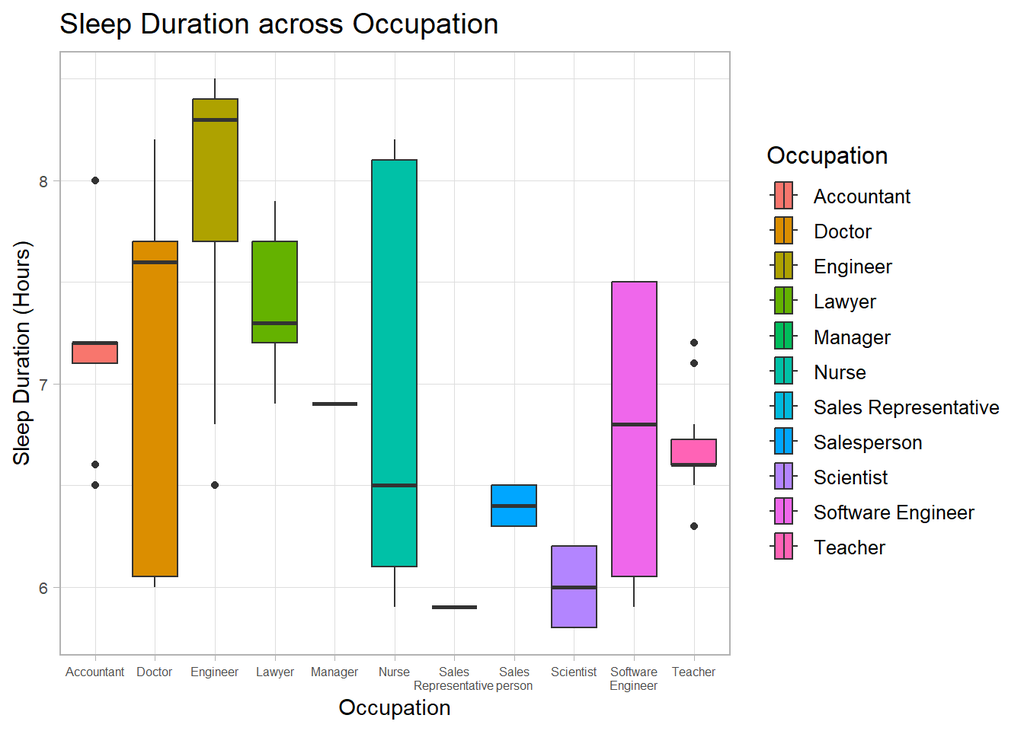

```r
# use the structure of `ggplot2` to properly plot `Sleep.Duration` and `Occupation`
# fill each boxplot by `Occupation`
ggplot(sleep_data, aes(x = Sleep.Duration, y = Occupation, fill = Occupation)) +
  geom_boxplot() +
# use `coord_flip()` to present vertical boxplots
  coord_flip() +
# label the x and y axes, title, and the y tick labels
  labs(x = "Sleep Duration (Hours)", y = "Occupation",
       title = "Sleep Duration across Occupation") +
  scale_y_discrete(labels = c("Accountant", "Doctor", "Engineer", "Lawyer",
                              "Manager", "Nurse", "Sales\nRepresentative",
                              "Sales\nperson", "Scientist", "Software\nEngineer", "Teacher")) +
# choose the `theme_light` and change the title and text sizes for each axis
  theme_light(base_size = 12) +
  theme(axis.title.x = element_text(size = 11), axis.title.y = element_text(size = 11),
        axis.text.x = element_text(size = 6), axis.text.y = element_text(size = 8))
```

Plot 1: Boxplot of `Sleep.Duration` across `Occupation`.

### Data Visualization #2

This second visualization plots `Stress.Level` over `Sleep.Duration` faceted by `Gender`. Using `geom_jitter()`, a scatterplot of stress level and hours of sleep can be plotted nicely with points easier to observe. In both `Female` and `Male`, `Stress.Level` has a negative association with `Sleep.Duration`, suggesting that increased hours of sleep reflect lower levels of stress.

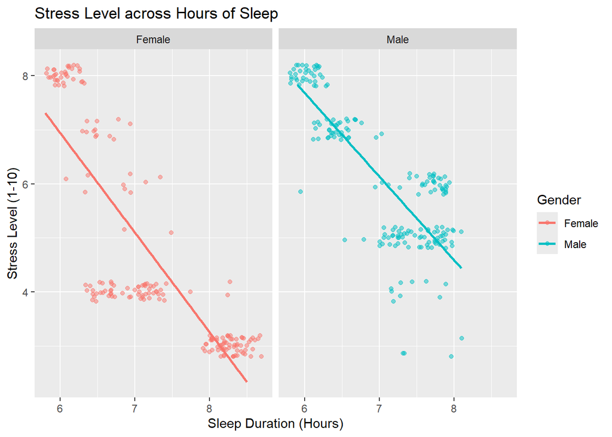

```r
# pipe `sleep_data`
sleep_data %>%
# use `select()` to gather columns of interest from the dataframe
  select(Gender, Stress.Level, Sleep.Duration) %>%
# drop any `NA` values from the columns using `drop_na()`
  drop_na(Gender, Stress.Level, Sleep.Duration) %>%
# use ggplot2, plotting `Sleep.Duration` on the x-axis and `Stress.Level` on the y-axis and color by `Gender`
  ggplot(aes(x = Sleep.Duration, y = Stress.Level, color = Gender)) +
# use `geom_jitter()` to smooth out the points, but set width and height to 0.2 to stay close to original data points.
# Set alpha to 0.5
  geom_jitter(width = 0.2, height = 0.2, alpha = 0.5) +
# add a trend line using `geom_smooth()`
  geom_smooth(method = "lm", se = FALSE) +
# split the plot into two subplots of `Gender` using `facet_wrap()`
  facet_wrap(~ Gender) +
# add x-axis, y-axis, and title labels to plot
  labs(x = "Sleep Duration (Hours)", y = "Stress Level (1-10)",
       title = "Stress Level across Hours of Sleep")
```

Plot 2: Scatterplot comparing the association of `Stress.Level` and `Sleep.Duration` between `Gender`.

### Visualization #3

This final visualization uses `geom_line()` to plot `Quality.of.Sleep` over `Sleep.Duration` faceted by `Sleep.Disorder`. This visualization explores the relationship between quality and amount of sleep, and how different sleeping disorders/no sleeping disorder affect this relationship. This plot uses summary statistics to smooth the line graph and reduce overplotting. In all three sub-plots, `Insomnia`, `None`, and `Sleep Apnea`, `Quality.of.Sleep` and `Sleep.Duration` have a positive association. However, we see that for `Insomnia` and `Sleep.Apnea`, getting 6 hours of sleep or less greatly lowers `Quality.of.Sleep` compared to having no sleep disorder.

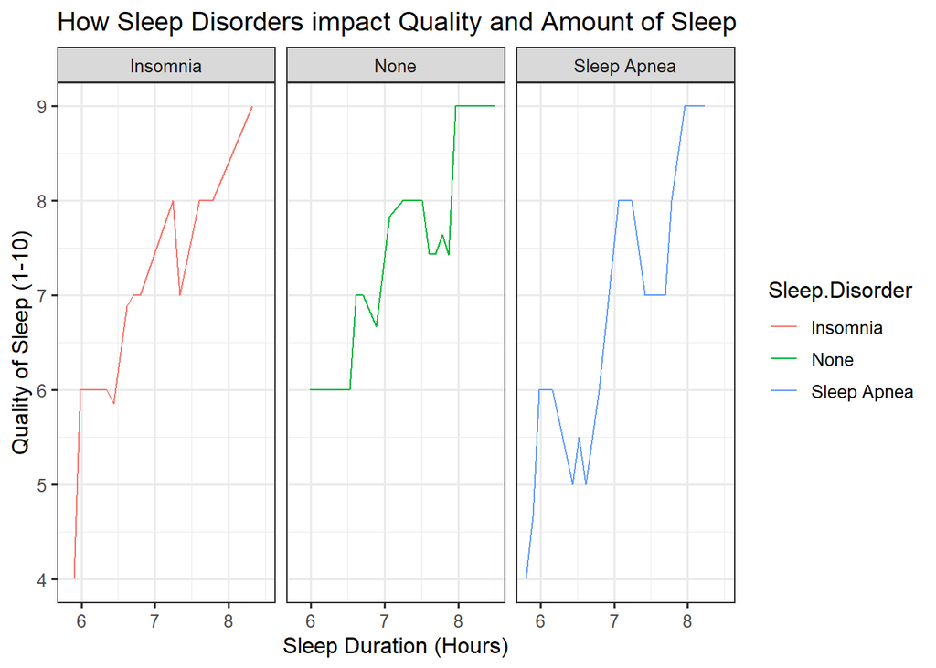

```r
# Pipe `sleep_data`
sleep_data %>%
# use `select()` to pull columns of interest for plotting
  select(Sleep.Disorder, Sleep.Duration, Quality.of.Sleep) %>%
# use `drop_na()` to remove any `NA` values from the columns of interest
  drop_na(Sleep.Disorder, Sleep.Duration, Quality.of.Sleep) %>%
# with ggplot2, plot `Sleep.Duration` on x-axis, `Quality.of.Sleep` on y-axis, and color by `Sleep.Disorder`
  ggplot(aes(x = Sleep.Duration, y = Quality.of.Sleep, color = Sleep.Disorder)) +
# `stat_summary_bin` to bin x values by 30 and take mean of y values to reduce over plotting
# "line" for `geom = `
  stat_summary_bin(fun = "mean", bins = 30, geom = "line") +
# use `facet_wrap()` to split data into subplots and avoid overlapping lines
  facet_wrap( ~ Sleep.Disorder) +
# add labels to x and y axes, and add a title
  labs(x = "Sleep Duration (Hours)", y = "Quality of Sleep (1-10)",
       title = "How Sleep Disorders impact Quality and Amount of Sleep") +
# select `theme_bw` and set base size = 12
  theme_bw(base_size = 12)
```

Plot 3: Line graph comparing `Quality.of.Sleep` with `Sleep.Duration` across `Sleep.Disorder`.

## Discussion

During this project, demographic and lifestyle variables from the dataset *Sleep_health_and_lifestyle_dataset.csv* were explored and visualized to identify potential associations with sleep health (Tharmalingam, 2024). After carrying out exploratory data analyses and creating data visualizations, findings can be reported:  
- `Sleep.Duration` medians vary among `Occupation`  
- For both females and males, stress levels decreased with increased amounts of sleep, indicating a negative association between `Stress.Level` and `Sleep.Duration`  
- `Quality.of.Sleep` had a positive association with `Sleep.Duration` for both individuals with sleeping disorders and without. However, for `Insomnia` and `Sleep Apnea`, getting 6 hours of sleep or less greatly lowers `Quality.of.Sleep` compared to individuals without a sleeping disorder  
Overall, the findings demonstrate that data visualization and exploratory data analysis are key tools for identifying and visualizing associations within data. Future studies to follow up this analysis include using the data *Sleep_health_and_lifestyle_dataset.csv* for statistical analyses, as well as considering additional datasets that include environmental variables that may affect sleep health, such as phone usage or screen time (Tharmalingam, 2024).

## Reference

Tharmalingam, L. (2024). *Sleep Health and Lifestyle Dataset* [Data set]. Kaggle. https://www.kaggle.com/datasets/uom190346a/sleep-health-and-lifestyle-dataset/data